# Sesion 19 - Calculo de Eventos Extremos

Juan Carlos Martinez-Ovando

Departamento Academico de Actuaria

Primavera 2019

# 1 Riesgos extremos

Revisaremos en esta sesion la forma de aproximar la probabilidad de la cola (i.e. *tail probability*), valor en riesgo (VaR) y valor en riesgo condicional (ES) del riesgo agregado
$$S
= \sum_{j=1}^N X_j$$
donde

- $N \sim Po(\lambda)$
- $X_j$s se distribuyen $LN(\mu, \sigma^2)$

Es decir, trabajamos en el contexto del enfoque de `riesgo colectivo`.

## 1.1 Observacion

Como comentamos en clase, la distribucion del monto agregado de siniestros,
$$F_S(s)=\sum_{n=0}^{\infty} F^{*(n)}_X(s)p_n,$$
depende fundamentalmente del calculo de $ F^{*(n)}_X(s)$, la convolucion de orden $n$ de la distribucion log-normal $LN(\mu, \sigma^2)$, la cual no puede obtenerse de manera sencilla.

De esta forma, en esta sesion calcularmos $F_S(s)$ mediante:

- Aproximaciones asintoticas
- Calculos por recursiones.

El ultimo se define con base en la discretizacion de $F_X(x)=LN(x|\mu, \sigma^2)$.

## 1.2 Otras observaciones

- Trabajaremos en el caso en que los parametros $(\lambda,\mu,\sigma^2)$ son conocidos.
- El `modulo` de **incertidumbre epistemica** es descartado, en este caso.

## 1.3 Variables iniciales

Empezamos definiendo algunas variables iniciales. Fijamos la tasa de intensidad de la distribucion Poisson (`lambda`), los parametros de media y varianza de la distribucion log-normal (`mu` y `sigma`, respectivamente), el umbral cuantilico (`q`) y el nivel cuantilico (`alpha`) para el calculo del VaR y ES.

```r
lambda <- 50
mu <- 5
sigma <- 1
q <- 20000
alpha <- 0.99
```

Definimos una funcion para calcular el primer momento de $F^{*(n)}(_X$, la distribucion de orden $n$ de la distribucion log-normal.

```r
LN.moment <- function(n, mu, sigma){
  #
  exp(n * mu + (n * sigma)^2 / 2)
}
```

Con base en esta funcion, calculamos:

- Valor esperado de $S$
- Varianza de $S$
- Sesgo de $S$,

En `R` obtenemos estas caracteristicas empleando el siguiente codigo.

```r
E.S <- lambda * LN.moment(1, mu, sigma)
var.S <- lambda * LN.moment(2, mu, sigma)
skew.S <- LN.moment(3, mu, sigma) / sqrt(lambda * (LN.moment(2, mu, sigma))^3)
FS.momentos <- as.data.frame(c(E.S,var.S,skew.S))
colnames(FS.momentos ) <- c("F_S")
rownames(FS.momentos ) <- c("Expectation","Variance","Skew")
FS.momentos
```

```
##                      F_S
## Expectation 1.223460e+04
## Variance    8.137740e+06
## Skew        6.338065e-01
```

# 2 Calculo de Probabilidades

## 2.1 Aproximacion Normal

La idea consiste en suponer que la distribucion de $S$ puede aproximarse por una distribucion normal
$$S \sim F_S(s) \approx N(s|\mu_S,\sigma_S^2),$$
donde $\mu_S$ es `E.S` y $\sigma_S^2$ es `var.S`.

En este caso, las probabilididades en la cola derecha de la distribucion se calculan en `R` para
$$\mathbb{P}(S > q),$$

$$VaR(S,\alpha),$$

y
$$ES(S,\alpha),$$

de la siguiente forma:

```r
tprob.S.norm <- pnorm(q, mean = E.S, sd = sqrt(var.S), lower.tail = FALSE)
VaR.S.norm <- E.S + sqrt(var.S) * qnorm(alpha)
ES.S.norm <- E.S + sqrt(var.S) * dnorm(qnorm(alpha)) / (1-alpha)
FS.tail.norm <- as.data.frame(c(tprob.S.norm ,VaR.S.norm ,ES.S.norm ))
colnames(FS.tail.norm) <- c("gaussian")
rownames(FS.tail.norm) <- c("Probability","VaR","E.S.")
FS.tail.norm
```

```
##                 gaussian
## Probability 3.242930e-03
## VaR         1.887090e+04
## E.S.        1.983758e+04
```

## 2.2 Gamma trasladada

La idea consiste en suponer que la distribucion de $S$ puede aproximarse por una distribucion gamma
$$S \sim F_S(s) \approx Ga(s-k|\gamma_1,\gamma_2),$$
donde $\gamma_1$ es el parametro `shape`, $\gamma_2$ es el parametro de escala `rate` y el parametro de traslacion es `k`. En `R`, estos parametros se obtienes como:

```r
shape <- (2/skew.S)^2
rate <- sqrt(shape/var.S)
k <- E.S - shape/rate
```

Asi, las estimaciones para las probabilididades en la cola derecha de la distribucion se calculan en `R` para $\mathbb{P}(S > q)=P(G > q-k)$, $VaR(S,\alpha)$ y $ES(S,\alpha)$ como:

```r
tprob.S.tg <- pgamma(q-k, shape, rate, lower.tail = FALSE)
VaR.S.tg <- k + qgamma(alpha, shape, rate)
ES.S.tg <- k + ((shape/rate) / (1-alpha)) *
          pgamma(qgamma(alpha, shape, rate),
                 shape = shape + 1, rate = rate, lower.tail = FALSE)
FS.tail.tg <- as.data.frame(c(tprob.S.tg ,VaR.S.tg ,ES.S.tg ))
colnames(FS.tail.tg) <- c("gamma-t")
rownames(FS.tail.tg) <- c("Probability","VaR","E.S.")
FS.tail.tg
```

```
##                  gamma-t
## Probability 1.103915e-02
## VaR         2.016044e+04
## E.S.        2.169567e+04
```

# 3 Recursion de Panjer

```r
nsteps <- 50000 # k; should be > floor(q)
stopifnot(nsteps + 1 >= floor(q))
```

## 3.1 Discretizacion de la distribucion de seeveridades marginales

Primero, mnecesitamos discretizar $F_X(x)$. Esto lo podemos realizar empleando el siguiente codigo en `R`.

```r
nsteps <- 50000
stopifnot(nsteps + 1 >= floor(q))

pts <- c(0, 1:(nsteps+1)- 0.5)
f <- diff(plnorm(pts, meanlog = mu, sdlog = sigma))
```

Notemos que estamos discretizando $\mathcal{X}$, i.e. $X$, en intervalos
$$(0, 0.5], (1/2, 1.5], (1.5, 2.5], \ldots$$

```r
FX_d <- cbind(pts,f)
```

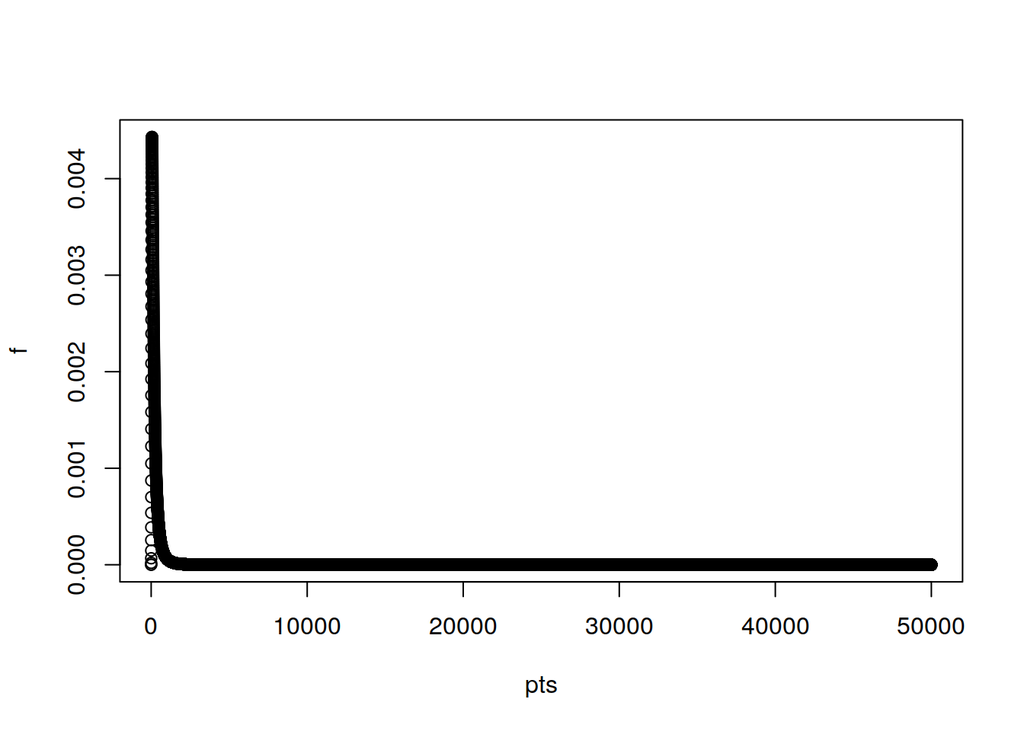

```r
plot(FX_d)
```

## 3.2 Calculos recursivos

Suponemos que las severidades individuales, $X_j$s con i.i.d. discretas con soporte en $\mathcal{X}=\{0,1,2,...\}$. Asi, las masas de probabilidad para esta version discretizada estan dadas por
$$f_k = P(X_1 = k),$$
para $k$ en $\mathcal{X}$. Suponemos ademas que $N$ es discreta, con soporte en
$$\mathcal{N}=\{0,1,2,...\}$$
con masas de probabilidad
$$p_k = P(N = k),$$
para $k$ en $\mathcal{N}$ tal que
$$p_k = (a+b/k) * p_{k-1}$$

para $k >= 1$ con $a + b >= 0 $.

Se considera $p_0$ como un parametro dado.

**NOTA:- La recursion de Panjer descansa en el supuesto que $N$ y $(X_j)_{j\geq 1}$ son mutuamente independientes.**

Dados los supuestos anteriores, la distribucion para $S$ resulta ser discreta con masas de probabilidades condicionales,
$$ps_{k,n} = P(S = k | N = n).$$

De esta forma, la masa de probabilidad $ps_{k,n+1}$ para $\{S=k\}$, condicional en $N = n+1$, puede calcularse recursivamente como
$$ps_{k,n+1} = \sum_{j=1}^{k-1} ps_{j,n} f_{k-j},$$
para todo $k$ en el soporte discretizado $\mathcal{S}$.

De esta forma, la recusion de Panker queda expresada como
$$ps_k = P(S = k)$$
para $k$ en el soporte $\mathcal{S}$, siendo
$$M_N(z) = \mathbb{E}_{P_N}(z^N),$$
la funcion generadora de momentos de $N$.

De esta forma, la recusion se define como

$$\begin{equation}
ps_0 = \begin{cases}
M_N(f_0), & \text{ si } \ \ a=0 \\
p_0/(1-f_0*a)^(1+b/a), & \text{ e.o.c.}
\end{cases}
\end{equation}$$
y
$$\begin{equation}
ps_k = (1-f_0 * a) \sum_{j=1}^k (a+bj/k) * f_j * ps_{k-j},
\end{equation}$$
para $k=1,2,\ldots$.

En `R` esta recursion queda definida como:

```
s_0 <- if(a == 0) G(f_0) else p_0/(1-f_0*a)^(1+b/a)
```

y

```
s_k <- (1-f_0*a) * sum_{j=1}^k (a+bj/k) * f_j * s_{k-j},
```

para $k = 1,2,\ldots$.

## 3.3 Caso Poisson

Particularmente, cuando
$$N \sim Po(\lambda),$$
se tiene que
$$M_N(z) = exp\{\lambda * (z-1)\},$$
con $a = 0$ y $b = \lambda$.

De esta forma, tenemos el siguiente calculo directo:

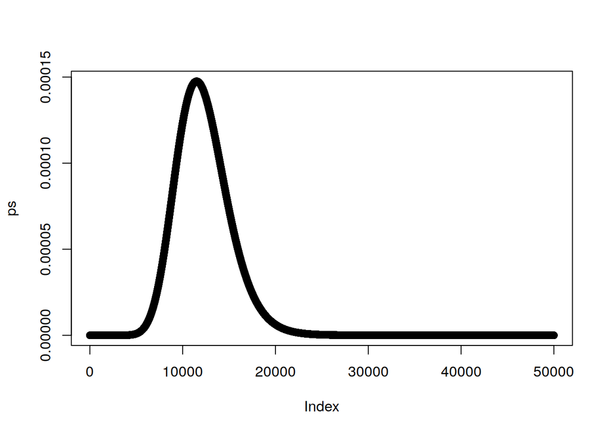

```r
a <- 0
b <- lambda
ps <- numeric(nsteps+1)
ps[1] <- exp(lambda * (f[1] - 1))
fct <- 1 - f[1] * a
for(k in 1:nsteps){
  j <- 1:k
  ps[k+1] <- fct * sum((a + b*j/k) * f[j+1] * ps[k-j+1])
}
plot(ps)
```

**NOTA:-** El objeto `ps` en `R` contiene las masas de probabilidad para $S$.

Con base en estas masas de probabilidad, calculamos las caracteristicas de interes:

- probabilidad sobre la cola derecha de la distribucion $F_S(s)$
- $VaR(S,\alpha)$
- $ES(S,\alpha)$.

> Usualmente, con `nsteps = 25000` los estimadores anteriores seran bien aproximados.

```r
Ps.df <- cumsum(ps)
tprob.S.pr <- 1 - Ps.df[floor(q)]
# Indices para los cuales S.df >= alpha
ii <- which(Ps.df >= alpha)
stopifnot(length(ii) > 0)
VaR.S.pr <- min(ii)
ES.S.pr <- sum((ii-1) * ps[ii]) / (1-alpha)
FS.tail.pr <- as.data.frame(c(tprob.S.pr ,VaR.S.pr ,ES.S.pr ))
colnames(FS.tail.pr) <- c("Panjer")
rownames(FS.tail.pr) <- c("Probability","VaR","E.S.")
FS.tail.pr
```

```
##                   Panjer
## Probability 1.080443e-02
## VaR         2.013400e+04
## E.S.        2.194206e+04
```

# 4 Resumen

En el siguiente objeto en `R` resumimos y comparamos las aproximaciones a la cola derecha de la distribuicion del monto agregado de siniestros $F_S(s)$.

Notemos que las aproximaciones de la distribucion normal son mas bajas que las de la distribucion aproximada por la distribiucion normal/gaussiana.

```r
FS.tail <- cbind(FS.tail.norm,FS.tail.tg,FS.tail.pr)
FS.tail
```

```
##                 gaussian      gamma-t       Panjer
## Probability 3.242930e-03 1.103915e-02 1.080443e-02
## VaR         1.887090e+04 2.016044e+04 2.013400e+04
## E.S.        1.983758e+04 2.169567e+04 2.194206e+04
```

En este caso, queda evidenciado que la aproximacion gaussiana no es adecuada, por hacer uso solo del primero y segundo momento de $F_S(s)$ (por consiguiente, no toma encuenta las caracteristicas asociadas con la forma en el extremo derecho de su distribucion, como lo hacen la segunda y tercera aproximacion).

# 5 Tarea

1. En la recursion de Panjer, comparen la probabilidad de que $S = k$ dado $N = n + 1$ con la probabilidad de alcanzar $j$ con $n$ sumandos y $k-j$ para el sumando restante.
2. Calculen las aproximaciones a la cola derecha de $F_S(s)$ que produjeron con el metodo de simulacion estocastica y comparenlo con lo que se obtienen en este ejercicio.
3. Relicen los mismos calculos reemplazando la distribucion $F_X(x)$ log-normal por cualquier otra distribucion para severidades individuales con soporte en $(0,\infty)$.